# ggplot visualization

```r
library(tidyverse)
```

## Crear una grafica del paquete mpg

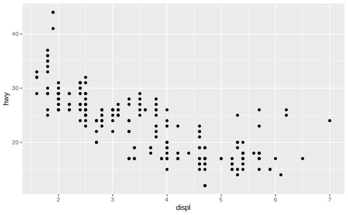

```r
ggplot(data = mpg) +
  geom_point(mapping = aes(x = displ, y = hwy))
```

probando hacer otra gráfica ¿ Será util esta gráfica?

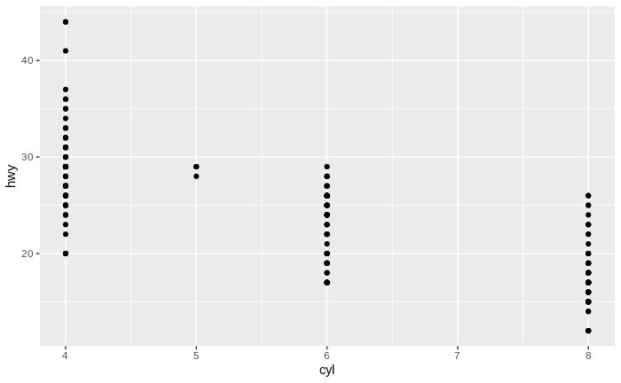

```r
ggplot(data = mpg)+
geom_point(mapping = aes(x= cyl,y=hwy))
```

¿Qué pasa si hacemos una gráfica de class vs drv? ¿ Resulta útil esta gráfica?

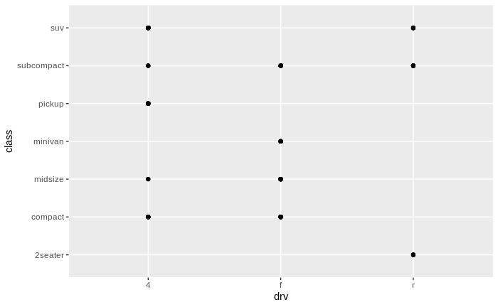

```r
ggplot(data=mpg)+
  geom_point(mapping = aes(x=drv,y=class))
```

**Respuesta: La gráfica no resulta de mucha utilidad puesto que estamos graficando una variable categórica en el eje y**

pueden representarse a través de propieades como el color o el tamaño de los puntos la asociación con diferentes variables. Vamoslo a continuación.

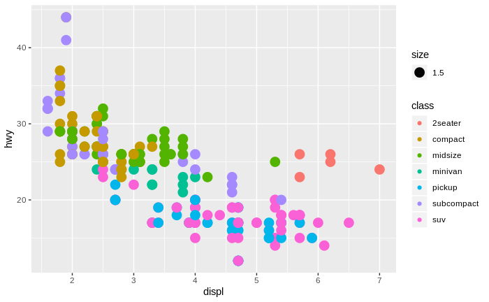

```r
ggplot(data = mpg)+
geom_point(mapping = aes(x=displ,y=hwy,color=class,size=1.5))
```

ahora veamos que pasa si el paramétro que describe el tipo de auto es el tamaño de los puntos en ves del color

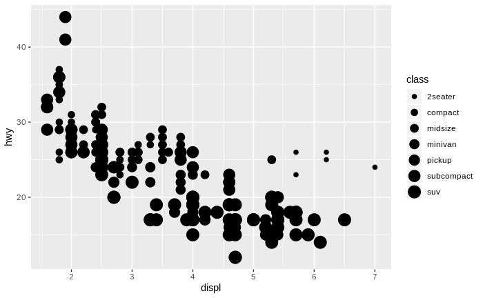

```r
ggplot(data = mpg) +
  geom_point(mapping = aes(x = displ, y = hwy, size = class))
```

tambien puede mapearse la clase modificando la transparencia de los puntos. vamoslo con el siguiente código

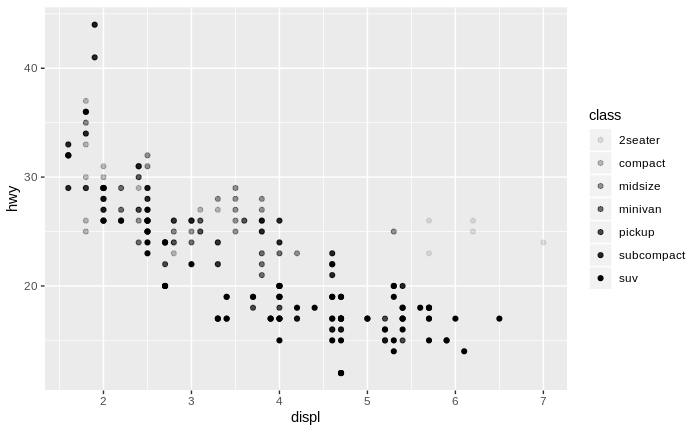

```r
## left
ggplot(data = mpg) +
  geom_point(mapping = aes(x = displ, y = hwy, alpha = class))
```

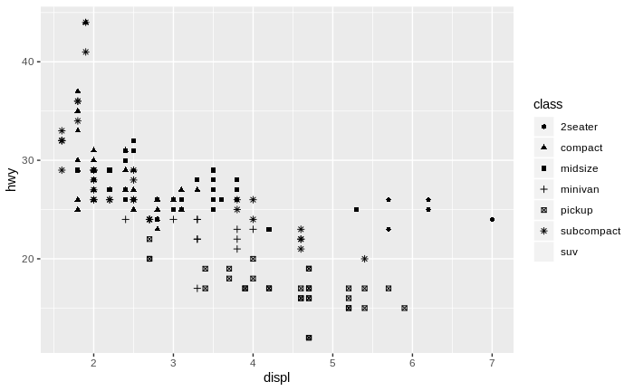

```r
# Right
ggplot(data = mpg) +
  geom_point(mapping = aes(x = displ, y = hwy, shape = class))
```

tambien puede modificarse simplemente el color de los puntos, sin que se mapee ninguna variable en particular:

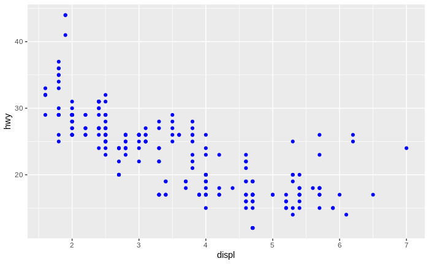

```r
ggplot(data = mpg) +
  geom_point(mapping = aes(x = displ, y = hwy), color = "blue")
```

En este caso el color debe estar afuera de los parámatros del mapping. De lo contrario R hace algo un poco extraño:

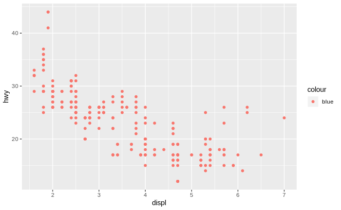

```r
ggplot(data = mpg) +
  geom_point(mapping = aes(x = displ, y = hwy ,color = "blue"))
```

## Haciendo facetas

con ggplot es posible generar multiples grafícas para describir la interacción de una variable con las demas. para esto se usan el argumento facet_wrap(~variable,…) y facet_grid() para describir las relaciones entre más de una variable.

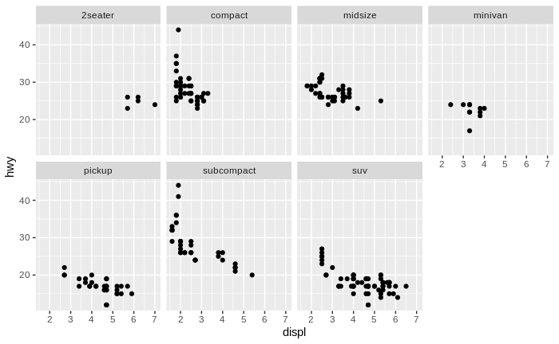

```r
ggplot(data = mpg)+
  geom_point(mapping = aes(x = displ, y =hwy))+
facet_wrap(~class, nrow=2)
```

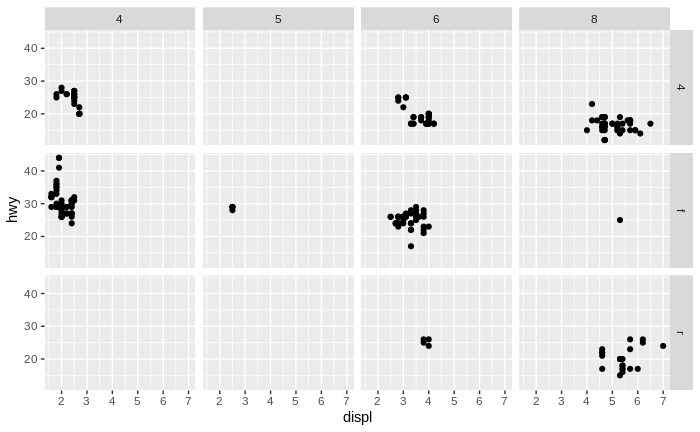

```r
ggplot(data = mpg)+
  geom_point(mapping = aes(x=displ,y=hwy))+
  facet_grid(drv ~ cyl)
```